# Project 1: Wrangling, Exploration, Visualization

SDS322E

## Data Wrangling, Exploration, Visualization

### Stacy Jong svj284

#### Introduction

For this project I chose to look at environmental data across different cities in the U.S. This is interesting to me as I have lived in multiple cities across the U.S. and have seen varying climates and how that has affected the local culture, lifestyles, etc. I obtained two datasets in R packages: Angell from the carData package and USairpollution from the HSAUR3 package. The Angell dataset contains data mapping cities to their regions, moral composition, mobility, etc. The USairpollution dataset maps cities to their population, average precipitation, average temperature, average wind speeds, average SO2 levels, etc. I would expect to see relationships in this data such as increasing SO2 levels with increasing population, higher annual temperatures in the South, higher mobility levels in the West, etc.

```r
library(tidyverse)
library(HSAUR3)
library(carData)
cities <- Angell
pollution <- USairpollution
```

#### Tidying: Reshaping

```r
pollution$city <- row.names(pollution)
cities$city <- row.names(cities)

tidy_cities <- cities
tidy_cities$city <- cities$city %>% str_replace_all("_", " ")
```

I tidied the datasets by first moving all the city names into a column of their own in both datasets(as the original datasets had the city names as row names). I then used str_replace_all() on the city variable in the cities dataset, since in the cities dataset, city names with two words were joined by an underscore while the city names in the pollution dataset were joined by a space. Thus I replaced the underscores in the city names in the cities dataset with a space to prepare for joining the two datasets in a later step.

I demonstrate using pivot_longer in the summary statistics section.

#### Joining/Merging

```r
joined <- inner_join(tidy_cities, pollution, by = "city")
joined <- joined %>% relocate(city)
```

I joined the two datasets by the ‘city’ variable, and I chose to do an inner join in order to drop the cities in either dataset that did not appear in the other dataset.

```r
nrow(tidy_cities)
```

```
## [1] 43
```

```r
nrow(pollution)
```

```
## [1] 41
```

```r
nrow(joined)
```

```
## [1] 20
```

```r
subset(tidy_cities, !(city %in% pollution$city))$city
```

```
##  [1] "Rochester"       "Syracuse"        "Worcester"       "Erie"
##  [5] "Bridgeport"      "Dayton"          "Reading"         "Peoria"
##  [9] "Trenton"         "Grand Rapids"    "Toledo"          "San Diego"
## [13] "South Bend"      "Akron"           "Tacoma"          "Flint"
## [17] "Spokane"         "Portland Oregon" "Fort Worth"      "Oklahoma City"
## [21] "Chattanooga"     "Birmingham"      "Tulsa"
```

```r
subset(pollution, !(city %in% tidy_cities$city))$city
```

```
##  [1] "Albany"         "Albuquerque"    "Charleston"     "Chicago"
##  [5] "Cincinnati"     "Hartford"       "Kansas City"    "Little Rock"
##  [9] "Minneapolis"    "New Orleans"    "Norfolk"        "Omaha"
## [13] "Philadelphia"   "Phoenix"        "Pittsburgh"     "Providence"
## [17] "Salt Lake City" "San Francisco"  "St. Louis"      "Washington"
## [21] "Wilmington"
```

```r
subset(tidy_cities, city %in% pollution$city)$city
```

```
##  [1] "Milwaukee"    "Buffalo"      "Des Moines"   "Cleveland"    "Denver"
##  [6] "Wichita"      "Baltimore"    "Detroit"      "Seattle"      "Indianapolis"
## [11] "Columbus"     "Richmond"     "Houston"      "Nashville"    "Dallas"
## [16] "Louisville"   "Jacksonville" "Memphis"      "Miami"        "Atlanta"
```

The total observations in the cities dataset is 43, the total observations in the pollution dataset is 41, and the total observations in the joined dataset is 20. Those values also correspond to the number of unique IDs in each dataset, as each dataset does not have a city observed more than once.

The IDs that appear in the cities dataset but not in the pollution dataset include: “Rochester”, “Syracuse”, “Worcester”, “Erie”, “Bridgeport”, “Dayton”, “Reading”, “Peoria”, “Trenton”, “Grand Rapids”, “Toledo”, “San Diego”, “South Bend”, “Akron”, “Tacoma”, “Flint”, “Spokane”, “Portland Oregon”, “Fort Worth”, “Oklahoma City”, “Chattanooga”, “Birmingham”, “Tulsa”

The IDs that appear in the pollutions dataset but not in the cities dataset include: “Albany”, “Albuquerque”, “Charleston”, “Chicago”, “Cincinnati”, “Hartford”, “Kansas City”, Little Rock“,”Minneapolis“,”New Orleans“,”Norfolk“,”Omaha“,”Philadelphia“,”Phoenix“,”Pittsburgh“,”Providence“,”Salt Lake City“,”San Francisco“,”St. Louis“,”Washington“,”Wilmington"

The IDs that appear in both datasets include: “Milwaukee”, “Buffalo”, “Des Moines”, “Cleveland”, “Denver”, “Wichita”, “Baltimore”, “Detroit”, “Seattle”, “Indianapolis”, “Columbus”, “Richmond”, “Houston”, “Nashville”, “Dallas”, “Louisville”, “Jacksonville”, “Memphis”, “Miami”, “Atlanta”

#### Wrangling

```r
library(gt)
range <- function(x, y) {
    y - x
}

# summary statistics for numeric variables
num_pivoted <- joined %>% pivot_longer(c(moral, hetero, mobility,
    SO2, temp, manu, popul, wind), names_to = "numeric_var",
    values_to = "val")

num_pivoted %>% group_by(numeric_var) %>% summarize(mean = mean(val),
    sd = sd(val), var = var(val), lower_quart = quantile(val,
        probs = c(0.24)), upper_quart = quantile(val, probs = c(0.75)),
    min = min(val), max = max(val), range = range(min, max))
```

```
## # A tibble: 8 x 9
##   numeric_var   mean     sd      var lower_quart upper_quart   min    max  range
##   <chr>        <dbl>  <dbl>    <dbl>       <dbl>       <dbl> <dbl>  <dbl>  <dbl>
## 1 hetero       40.0   21.7    4.70e2       23.2         52.   11.9   84.5   72.6
## 2 manu        426.   272.     7.38e4      240.         583   104   1064    960
## 3 mobility     27.3    8.88   7.89e1       19.5         34.3  12.1   42.7   30.6
## 4 moral        10.1    3.55   1.26e1        7.87        13.7   4.2   15.8   11.6
## 5 popul       628.   318.     1.01e5      456.         747.  201   1513   1312
## 6 SO2          22.5   14.3    2.06e2       10.6         28.2   8     65     57
## 7 temp         56.7    8.14   6.62e1       50.6         61.5  45.7   75.5   29.8
## 8 wind          9.85   1.45   2.11e0        8.91        10.9   7.6   12.7    5.1
```

```r
# summary statistics for categorical variable - region
joined %>% group_by(region) %>% summarize(count = n())
```

```
## # A tibble: 4 x 2
##   region count
##   <fct>  <int>
## 1 E          2
## 2 MW         7
## 3 S          9
## 4 W          2
```

```r
# summary statistics for categorical variable - city
joined %>% group_by(city) %>% summarize(count = n())
```

```
## # A tibble: 20 x 2
##    city         count
##    <chr>        <int>
##  1 Atlanta          1
##  2 Baltimore        1
##  3 Buffalo          1
##  4 Cleveland        1
##  5 Columbus         1
##  6 Dallas           1
##  7 Denver           1
##  8 Des Moines       1
##  9 Detroit          1
## 10 Houston          1
## 11 Indianapolis     1
## 12 Jacksonville     1
## 13 Louisville       1
## 14 Memphis          1
## 15 Miami            1
## 16 Milwaukee        1
## 17 Nashville        1
## 18 Richmond         1
## 19 Seattle          1
## 20 Wichita          1
```

```r
# summary statistic grouped by categorical variable
together <- num_pivoted %>% group_by(region, numeric_var) %>%
    summarize(mean = mean(val), sd = sd(val), var = var(val),
        lower_quart = quantile(val, probs = c(0.24)), upper_quart = quantile(val,
            probs = c(0.75)), min = min(val), max = max(val))

together %>% gt %>% tab_header(title = md("**Summary Statistics**"),
    subtitle = md("Summary Statistics Grouped by U.S. Region"))
```

**Summary Statistics**

Summary Statistics Grouped by U.S. Region

| numeric_var | mean | sd | var | lower_quart | upper_quart | min | max |
| --- | --- | --- | --- | --- | --- | --- | --- |
| E |  |  |  |  |  |  |  |
| hetero | 34.050000 | 16.6170094 | 2.761250e+02 | 27.940 | 39.925 | 22.3 | 45.8 |
| manu | 508.000000 | 165.4629868 | 2.737800e+04 | 447.160 | 566.500 | 391.0 | 625.0 |
| mobility | 13.400000 | 1.8384776 | 3.380000e+00 | 12.724 | 14.050 | 12.1 | 14.7 |
| moral | 13.600000 | 2.2627417 | 5.120000e+00 | 12.768 | 14.400 | 12.0 | 15.2 |
| popul | 684.000000 | 312.5411973 | 9.768200e+04 | 569.080 | 794.500 | 463.0 | 905.0 |
| SO2 | 29.000000 | 25.4558441 | 6.480000e+02 | 19.640 | 38.000 | 11.0 | 47.0 |
| temp | 51.050000 | 5.5861436 | 3.120500e+01 | 48.996 | 53.025 | 47.1 | 55.0 |
| wind | 11.000000 | 1.9798990 | 3.920000e+00 | 10.272 | 11.700 | 9.6 | 12.4 |
| MW |  |  |  |  |  |  |  |
| hetero | 25.228571 | 11.5229791 | 1.327790e+02 | 14.768 | 33.750 | 11.9 | 39.7 |
| manu | 499.428571 | 398.2088469 | 1.585703e+05 | 187.040 | 788.000 | 104.0 | 1064.0 |
| mobility | 25.485714 | 9.0261525 | 8.147143e+01 | 18.996 | 28.450 | 17.6 | 42.7 |
| moral | 12.200000 | 2.9490111 | 8.696667e+00 | 9.812 | 14.050 | 8.0 | 15.8 |
| popul | 677.857143 | 431.2912506 | 1.860121e+05 | 392.720 | 748.500 | 201.0 | 1513.0 |
| SO2 | 27.857143 | 18.6496521 | 3.478095e+02 | 16.440 | 31.500 | 8.0 | 65.0 |
| temp | 50.671429 | 3.3549537 | 1.125571e+01 | 49.308 | 51.900 | 45.7 | 56.6 |
| wind | 10.714286 | 1.3704361 | 1.878095e+00 | 9.876 | 11.500 | 8.6 | 12.7 |
| S |  |  |  |  |  |  |  |
| hetero | 57.666667 | 17.5131379 | 3.067100e+02 | 48.024 | 70.600 | 31.5 | 84.5 |
| manu | 352.555556 | 200.4732595 | 4.018953e+04 | 206.200 | 368.000 | 136.0 | 721.0 |
| mobility | 30.266667 | 7.2380937 | 5.239000e+01 | 25.360 | 36.100 | 19.4 | 41.8 |
| moral | 7.288889 | 2.2391094 | 5.013611e+00 | 5.376 | 8.600 | 4.2 | 10.4 |
| popul | 600.222222 | 287.3215872 | 8.255369e+04 | 438.960 | 624.000 | 299.0 | 1233.0 |
| SO2 | 16.777778 | 8.0588116 | 6.494444e+01 | 10.000 | 24.000 | 9.0 | 30.0 |
| temp | 63.877778 | 6.3491688 | 4.031194e+01 | 59.272 | 68.400 | 55.6 | 75.5 |
| wind | 9.066667 | 1.1489125 | 1.320000e+00 | 8.268 | 9.200 | 7.6 | 10.9 |
| W |  |  |  |  |  |  |  |
| hetero | 18.450000 | 7.7074639 | 5.940500e+01 | 15.616 | 21.175 | 13.0 | 23.9 |
| manu | 416.500000 | 53.0330086 | 2.812500e+03 | 397.000 | 435.250 | 379.0 | 454.0 |
| mobility | 34.350000 | 0.2121320 | 4.500000e-02 | 34.272 | 34.425 | 34.2 | 34.5 |
| moral | 11.450000 | 3.4648232 | 1.200500e+01 | 10.176 | 12.675 | 9.0 | 13.9 |
| popul | 523.000000 | 11.3137085 | 1.280000e+02 | 518.840 | 527.000 | 515.0 | 531.0 |
| SO2 | 23.000000 | 8.4852814 | 7.200000e+01 | 19.880 | 26.000 | 17.0 | 29.0 |
| temp | 51.500000 | 0.5656854 | 3.200000e-01 | 51.292 | 51.700 | 51.1 | 51.9 |
| wind | 9.200000 | 0.2828427 | 8.000000e-02 | 9.096 | 9.300 | 9.0 | 9.4 |

For the summary statistics for numeric variables, I generated statistics for the hetero, manu, mobility, moral, popul, SO2, temp, and wind variables. For each variable I calculated the mean, standard deviation, variance, lower quartile, upper_quartile, minimum, maximum, and range values. For the two categorical variables, region and city, I generated a table showing the counts for each category. Finally, I generated a table for the summary statistics grouped by region and the numeric variable. This table was also stylized using the gt package.

```r
joined %>% mutate(daily_precip = precip/predays) %>% arrange(desc(daily_precip))
```

```
##           city moral hetero mobility region SO2 temp manu popul wind precip
## 1 Jacksonville   6.0   73.7     27.7      S  14 68.4  136   529  8.8  54.47
## 2      Houston  10.2   49.0     36.1      S  10 68.9  721  1233 10.8  48.19
## 3      Memphis   5.4   84.5     26.7      S  10 61.6  337   624  9.2  49.10
## 4        Miami   5.1   50.2     41.8      S  10 75.5  207   335  9.0  59.80
## 5       Dallas   8.0   36.8     37.8      S   9 66.2  641   844 10.9  35.94
## 6      Atlanta   4.2   70.6     32.6      S  24 61.5  368   497  9.1  48.34
## 7    Nashville   8.6   57.4     25.4      S  18 59.4  275   448  7.9  46.00
##   predays daily_precip
## 1     116    0.4695690
## 2     103    0.4678641
## 3     105    0.4676190
## 4     128    0.4671875
## 5      78    0.4607692
## 6     115    0.4203478
## 7     119    0.3865546
##  [ reached 'max' / getOption("max.print") -- omitted 13 rows ]
```

```r
joined %>% select(region, mobility) %>% group_by(region) %>%
    summarize(avg_mobility = mean(mobility)) %>% arrange(desc(avg_mobility))
```

```
## # A tibble: 4 x 2
##   region avg_mobility
##   <fct>         <dbl>
## 1 W              34.4
## 2 S              30.3
## 3 MW             25.5
## 4 E              13.4
```

```r
joined %>% filter(region == "W") %>% arrange(desc(mobility))
```

```
##      city moral hetero mobility region SO2 temp manu popul wind precip predays
## 1  Denver  13.9   13.0     34.5      W  17 51.9  454   515  9.0  12.95      86
## 2 Seattle   9.0   23.9     34.2      W  29 51.1  379   531  9.4  38.79     164
```

NOTE: str_replace_all with regex was used previously in the tidying section.

#### Visualizing

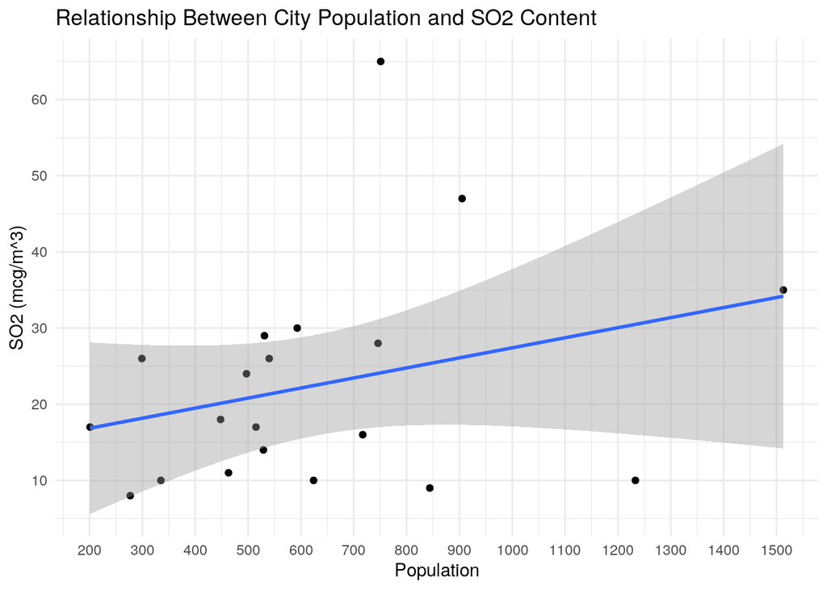

```r
ggplot(joined, aes(x = popul, y = SO2)) + geom_point() + geom_smooth(method = "lm") +
    theme_minimal() + scale_y_continuous(breaks = seq(0, 70,
    10)) + scale_x_continuous(breaks = seq(0, 2000, 100)) + ggtitle("Relationship Between City Population and SO2 Content") +
    xlab("Population") + ylab("SO2 (mcg/m^3)")
```

This visualization plots the population of individual cities against their corresponding values for SO2 content in the air in micrograms per cubic metre. A linear regression line was fitted to the plot, showing a positive linear relationship between population and SO2 content. However, the relationship is rather weak as the points do not closely follow the line, and there are a few outliers.

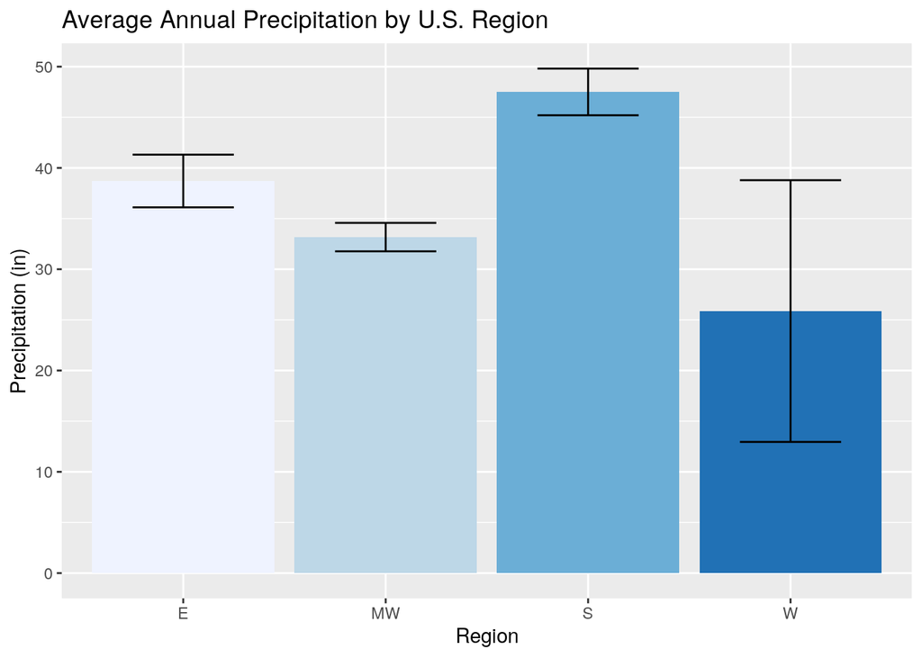

```r
ggplot(joined, aes(x = region, y = precip)) + geom_bar(stat = "summary",
    fun = mean, aes(fill = region)) + geom_errorbar(stat = "summary",
    fun.data = mean_se, width = 0.5) + theme(legend.position = "none") +
    scale_y_continuous(breaks = seq(0, 60, 10)) + scale_fill_brewer() +
    ggtitle("Average Annual Precipitation by U.S. Region") +
    ylab("Precipitation (in)") + xlab("Region")
```

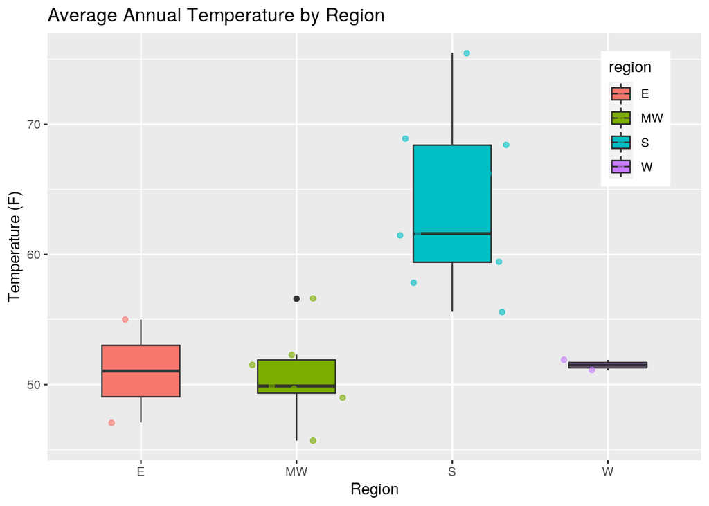

```r
ggplot(joined, aes(x = region, y = temp, fill = region)) + geom_boxplot(width = 0.5,
    aes(fill = region)) + geom_jitter(alpha = 0.6, aes(color = region)) +
    theme(legend.position = c(0.9, 0.8)) + ggtitle("Average Annual Temperature by Region") +
    ylab("Temperature (F)") + xlab("Region")
```

This is a boxplot of the average annual temperature in Fahrenheit across the different regions of the United States(East, Midwest, South, and West). From this plot we can see that the mean temperature for the South is significantly higher than the other three regions, whereas East, Midwest, and West all have similar average temperatures. Additionally, the South has a much wider interquartile range compared to the other three regions, suggesting that average temperatures vary significantly across different cities in the South.